# **Exploring the World of Cosmetics: A Data-Driven Approach**

#### By Martina Vasconez and Disha Amin

##### [Link to our github webpage](https://martinavasconez.github.io/Data-Science/)

## Project Goals

Have you ever wondered if expensive cosmetics are actually safer for your health? In this project, we aim to answer this question using a data-driven approach.

We will explore the chemicals and substances commonly found in beauty and cosmetic products. Our objective is to analyze how these chemicals are priced and their potential effects on human health. This will help us determine if higher-priced products are genuinely better for consumers' health—or if the perception of safety is just an illusion.

**Why does this matter?**

- **For consumers:** Price often plays a big role in purchasing decisions. People tend to associate higher prices with better quality, especially in the cosmetics industry.
- **For health:** Chemicals in cosmetics can cause bodily irritations and other health problems. Understanding the relationship between price and chemical composition can help consumers make safer choices.

**Our Hypothesis:**

If certain beauty products are priced higher, then the chemicals in them should cause fewer bodily irritations and health problems. Expensive products give consumers the impression that they are better for human bodies—but is this really the case?

**How we'll explore this:**

To support our analysis, we will gather data from relevant datasets that illustrate the relationships between product pricing, chemical composition, and associated health impacts.

By analyzing this data, we hope to uncover meaningful insights into the safety of cosmetics and the factors that influence consumer perception.

## Collaboration Plan

To ensure efficiency and effective teamwork in our project, we have established a comprehensive collaboration plan.

- **Weekly Meetings:** We plan to meet once a week in the afternoons, or more frequently if needed, to discuss project progress, share updates, and address any challenges we may face.
- **Communication:** We have exchanged contact information to facilitate ongoing communication. This will enable us to quickly discuss ideas, ask questions, or resolve issues that may arise.
- **Remote Collaboration:** We have created a shared document and a Google Colab notebook that facilitate remote collaboration. The document will serve as a central location for notes, project outlines, and any research findings we gather outside of our scheduled meetings. Meanwhile, the Google Colab notebook will be dedicated to coding.

By adhering to this collaboration plan, we aim to maintain clear communication and ensure that all aspects of our project are completed efficiently and effectively.

## Key Datasets for Investigation

Our analysis utilizes three primary datasets that address key aspects of our exploration into cosmetic chemicals and their implications for human health:

[Cosmetics Dataset](https://www.kaggle.com/datasets/kingabzpro/cosmetics-datasets): This dataset provides detailed information about various cosmetic companies, their products (categorized by type), ingredients, and prices. It serves as the foundation for analyzing trends in pricing, ingredient composition, and product categories.

**What we analyze from this dataset:**

- Which products contain specific chemicals?
- How are prices distributed across brands and product types?
- Are higher-priced products associated with specific ingredients or categories?

[ECHA Europa C & L Inventory](https://echa.europa.eu/information-on-chemicals/cl-inventory-database): This database is sourced from ECHA Europa and focuses on the hazard classifications of individual chemicals. Each chemical is linked to a unique CAS Number and is categorized based on hazard notifications from companies and manufacturers.

**What we analyze from this dataset:**

- The frequency and severity of hazard notifications.
- Patterns between chemical hazards and product pricing.
- Specific hazard codes related to skin, eye, respiratory irritation, and environmental toxicity.

[Environmental Working Group (EWG) Skin Deep Cosmetics Database](https://www.ewg.org/skindeep/): This database provides comprehensive ratings for common cosmetic chemicals based on factors like carcinogenic potential, immunotoxicity, and reproductive toxicity. This dataset is particularly valuable for building our model, as it provides health ratings that are relevant to the recreational use of cosmetics.

We will use this database after determining the average prices for chemicals to extract their comprehensive health rating and build our model. The health hazards found here are more relevant to recreational use, whereas the ECHA Europa C&L Inventory provides a more general overview of hazard data for all types of use and is better suited for preliminary analysis. This database is also an excellent resource for consumers looking to research products before buying them.

**Why These Datasets Matter Together**

By integrating these datasets, we can:

- Connect product prices to chemical composition and associated health hazards.
- Investigate how pricing impacts safety, uncovering whether expensive products are truly safer.
- Lay the groundwork for predictive models to inform consumers and provide actionable insights to the cosmetics industry.

## Data Exploration & ETL

We began our analysis with the cosmetics dataset to gain insights into the beauty industry. This dataset consists of 11 columns, including **Label, Brand, Price, and Name**. Our initial focus was on exploring this dataset in depth to provide context and understand its structure. Through this analysis, we aimed to uncover trends like price distribution, product rankings, and other relevant aspects of the cosmetics market.

Next, we expanded our investigation by exploring chemicals based on price ranges. By categorizing products into different price tiers (e.g., lowest, 25th percentile, median, and highest), we were able to identify patterns in ingredient usage across these categories. This approach allowed us to integrate the cosmetics data with hazard data from the ECHA Europa database, providing a deeper understanding of how product characteristics, chemical compositions, and associated health risks are interconnected.

## Importing Necessary Libraries

To work through this tutorial, we’ll use several Python libraries that are essential for data manipulation, visualization, and modeling. Each library has its own specific purpose:

- pandas: For data manipulation and analysis.
- matplotlib.pyplot and seaborn: For creating and styling visualizations.
- requests: For making HTTP requests (used for web scraping).
- BeautifulSoup: For parsing HTML content when working with web-scraped data.
- sklearn: For building machine learning models and preprocessing data.

If you’re new to any of these libraries, here are some helpful resources to learn more:

- [Pandas Documentation](https://pandas.pydata.org/docs/getting_started/index.html#getting-started)
- [Matplotlib Documentation](https://matplotlib.org/stable/index.html)
- [Seaborn Documentation](https://seaborn.pydata.org/)
- [BeautifulSoup Documentation](https://www.crummy.com/software/BeautifulSoup/bs4/doc/)
- [Scikit-learn Documentation](https://scikit-learn.org/stable/)

Feel free to explore these links if you’d like to dive deeper into how each library works!

```python
import pandas as pd
import matplotlib.pyplot as plt
import seaborn as sns
import requests
import numpy as np
from bs4 import BeautifulSoup
from io import StringIO
# For building our model
from sklearn.feature_extraction import DictVectorizer
from sklearn.preprocessing import StandardScaler
from sklearn.neighbors import KNeighborsRegressor
```

## Loading the Cosmetics Dataset

Let’s start our analysis by loading the cosmetics dataset into a DataFrame. This dataset serves as the foundation for our exploration of product pricing, ingredients, and their potential health impacts.

```python
# Load the cosmetics dataset
data = pd.read_csv('cosmetics.csv')
```

```python
from google.colab import drive
drive.mount('/content/drive')
```

## Displaying the First Few Rows of the Dataset

To get a **quick overview** of the cosmetics dataset, we can display its first five rows using the .head() function in pandas. This gives us an idea of the structure of the data and what kind of information it contains.

We discover that the dataset provides information on the product, brand, category, price, rank, ingredients, and skin compatibility.

```python
data.head()
```

|  | Label | Brand | Name | Price | Rank | Ingredients | Combination | Dry | Normal | Oily | Sensitive |
| --- | --- | --- | --- | --- | --- | --- | --- | --- | --- | --- | --- |
| 0 | Moisturizer | LA MER | Crème de la Mer | 175 | 4.1 | Algae (Seaweed) Extract, Mineral Oil, Petrolat... | 1 | 1 | 1 | 1 | 1 |
| 1 | Moisturizer | SK-II | Facial Treatment Essence | 179 | 4.1 | Galactomyces Ferment Filtrate (Pitera), Butyle... | 1 | 1 | 1 | 1 | 1 |
| 2 | Moisturizer | DRUNK ELEPHANT | Protini™ Polypeptide Cream | 68 | 4.4 | Water, Dicaprylyl Carbonate, Glycerin, Ceteary... | 1 | 1 | 1 | 1 | 0 |
| 3 | Moisturizer | LA MER | The Moisturizing Soft Cream | 175 | 3.8 | Algae (Seaweed) Extract, Cyclopentasiloxane, P... | 1 | 1 | 1 | 1 | 1 |
| 4 | Moisturizer | IT COSMETICS | Your Skin But Better™ CC+™ Cream with SPF 50+ | 38 | 4.1 | Water, Snail Secretion Filtrate, Phenyl Trimet... | 1 | 1 | 1 | 1 | 1 |

The dataset contains 11 columns: **Label, Brand, Name, Price, Rank, Ingredients, Combination, Dry, Normal, Oily, Sensitive**.

For our analysis, the relevant columns are **Label, Brand, Name, Price, Rank,** and **Ingredients**. Therefore, we will drop the other columns that are not necessary for our current focus.

```python
# Dropping irrelevant columns to streamline the analysis
data = data[['Label', 'Brand', 'Name', 'Price', 'Rank', 'Ingredients']]
```

## Let's check the general information about the dataset

Before diving into the analysis, it’s essential to understand the overall structure of the dataset. This helps us identify potential issues, such as missing values or incorrect data types, that may need cleaning.

Here’s what we’ll check:

**Null Values:**

Missing data can cause errors or biases in the analysis. By identifying columns with null values, we can decide how to handle them.

**Data Types:**

Understanding the data types—such as object (text), int64 (integers), or float64 (decimals)—helps us determine what operations can be performed on each column.

Let’s explore this information using .info() in pandas:

```python
data.info()
```

```
<class 'pandas.core.frame.DataFrame'>
RangeIndex: 1472 entries, 0 to 1471
Data columns (total 6 columns):
 #   Column       Non-Null Count  Dtype
---  ------       --------------  -----
 0   Label        1472 non-null   object
 1   Brand        1472 non-null   object
 2   Name         1472 non-null   object
 3   Price        1472 non-null   int64
 4   Rank         1472 non-null   float64
 5   Ingredients  1472 non-null   object
dtypes: float64(1), int64(1), object(4)
memory usage: 69.1+ KB
```

From the summary above, we can observe the following key points about the dataset:

**1. No Missing Values**

The dataset contains **1,472 entries**, and none of the columns have null values. This means no cleaning is required to handle missing data.

**2. Data Types**

The data types for each column are appropriate for their content:

- **Label, Brand, Name, Ingredients**: Object type is appropriate because these columns represent categorical data, allowing us to classify products by their brand, name, and ingredients.
- **Price**: Integer type, appropriate for representing the price of products.
- **Rank**: Identified as a float, this is suitable because it can accommodate decimal values, reflecting cases where products may have fractional rankings.

**Why this matters?**

Understanding the data structure ensures that the dataset is ready for analysis. Since the data types are correct and there are no null values, we can proceed with further exploration and transformations without additional cleaning.

## Tidy Data Principles: Creating Separate Datasets

To follow tidy data principles, we will restructure the dataset into two separate tables. This ensures that each type of entity—**products** and **ingredients**—is stored in its own table. Properly organizing the data makes it easier to analyze and retrieve information efficiently.

#### Product Information Table

```python
# Ensure each product is unique by considering all relevant columns
products_df = data[['Label', 'Brand', 'Name', 'Price', 'Rank']].drop_duplicates().reset_index(drop=True)

# Add a unique Product_ID column
products_df['Product_ID'] = products_df.index

products_df.set_index('Product_ID', inplace=True)

products_df.head()
```

| Product_ID | Label | Brand | Name | Price | Rank |
| --- | --- | --- | --- | --- | --- |
| 0 | Moisturizer | LA MER | Crème de la Mer | 175 | 4.1 |
| 1 | Moisturizer | SK-II | Facial Treatment Essence | 179 | 4.1 |
| 2 | Moisturizer | DRUNK ELEPHANT | Protini™ Polypeptide Cream | 68 | 4.4 |
| 3 | Moisturizer | LA MER | The Moisturizing Soft Cream | 175 | 3.8 |
| 4 | Moisturizer | IT COSMETICS | Your Skin But Better™ CC+™ Cream with SPF 50+ | 38 | 4.1 |

This table contains general information about the products, such as the label, brand, price, and rank. Each product is assigned a unique **Product ID.**

#### Ingredients Table

```python
# Reset the index of the products DataFrame to prepare for merging with the ingredients DataFrame
products_df.reset_index(inplace=True)

# Create the ingredients dataframe and dropping duplicates
ingredients_df = data[['Name', 'Ingredients']].drop_duplicates()

# Split the Ingredients column into a list for each row
ingredients_df['Ingredients'] = ingredients_df['Ingredients'].str.split(',')

# Explode the Ingredients column so that each ingredient has its own row
ingredients_df = ingredients_df.explode('Ingredients')

# Remove leading/trailing spaces
ingredients_df['Ingredients'] = ingredients_df['Ingredients'].str.strip()

ingredients_df = ingredients_df.merge(products_df[['Product_ID', 'Name']], on='Name', how='left')

ingredients_df = ingredients_df[['Product_ID', 'Ingredients']]

ingredients_df.head()
```

|  | Product_ID | Ingredients |
| --- | --- | --- |
| 0 | 0 | Algae (Seaweed) Extract |
| 1 | 0 | Mineral Oil |
| 2 | 0 | Petrolatum |
| 3 | 0 | Glycerin |
| 4 | 0 | Isohexadecane |

This table lists the **ingredients** associated with each product. The **Product ID** acts as a key to link the ingredients back to the corresponding product in the Product Table.

# Exploratory Data Analysis -- Cosmetics Dataset

### Summary Statistics for Numerical Columns

Next, we examine the summary statistics for the numerical columns in our dataset: **Price** and **Rank**. These statistics provide valuable insights into the data, including:

**Measures of central tendency:** The mean and median show us the typical values for product prices and rankings.

**Measures of variability:** The standard deviation, minimum, and maximum values help us understand the spread of the data and identify any outliers.

Understanding these statistics will help us identify potential trends and anomalies in the data, which will be important for our subsequent analyses.

```python
products_df.set_index('Product_ID', inplace=True)
products_df.describe()
```

|  | Price | Rank |
| --- | --- | --- |
| count | 1472.000000 | 1472.000000 |
| mean | 55.584239 | 4.153261 |
| std | 45.014429 | 0.633918 |
| min | 3.000000 | 0.000000 |
| 25% | 30.000000 | 4.000000 |
| 50% | 42.500000 | 4.300000 |
| 75% | 68.000000 | 4.500000 |
| max | 370.000000 | 5.000000 |

The summary statistics for the **Price** and **Rank** columns reveal important insights into the cosmetics dataset. The average price of products is approximately 55.58, with a wide standard deviation of 45.01, indicating considerable variability in pricing among different brands. Notably, prices range from a low of 3.00 to a high of 370.00 dollars. In terms of rankings, the average score is 4.15, suggesting that most products are rated favorably, with a maximum rank of 5.00.These insights highlight the diversity in both pricing and perceived quality among cosmetics, setting the stage for deeper analyses into their relationships.

## Distribution of Categorical Columns

### Distribution of Product Types

To understand the composition of the cosmetics dataset, we analyzed the distribution of **product types** using the value_counts() function. This reveals how many products fall into each category. Here's the result:

```python
products_df['Label'].value_counts()
```

| Label | count |
| --- | --- |
| Moisturizer | 298 |
| Cleanser | 281 |
| Face Mask | 266 |
| Treatment | 248 |
| Eye cream | 209 |
| Sun protect | 170 |

**dtype:** int64

From this data, we observe that **Moisturizers** are the most common product type, followed closely by Cleansers and Face Masks. This suggests that there is a strong market focus on moisturizing products in the cosmetics industry. The lower counts for **Sun Protect** and **Eye Creams** may indicate niche markets, providing insights into consumer preferences and potential areas for further exploration.

## Distribution of Brands

To understand the market landscape, we analyzed the distribution of **brands** in the cosmetics dataset. Using the value_counts() function, we identified the number of products offered by each brand. Here's the result:

```python
products_df['Brand'].value_counts()
```

| Brand | count |
| --- | --- |
| CLINIQUE | 79 |
| SEPHORA COLLECTION | 66 |
| SHISEIDO | 63 |
| ORIGINS | 54 |
| MURAD | 47 |
| ... | ... |
| SON & PARK | 1 |
| MAKEUP ERASER | 1 |
| KAT VON D | 1 |
| NURSE JAMIE | 1 |
| DERMAFLASH | 1 |

116 rows × 1 columns

**dtype:** int64

This distribution suggests that certain well-established brands like **CLINIQUE, SEPHORA COLLECTION, and SHISEIDO** dominate the cosmetics market in terms of the number of products they offer. In contrast, there are niche brands with only a few or a single product, which could indicate specialization or limited product lines. This variety allows for deeper analysis into how brand popularity correlates with pricing, ingredients, and product rankings.

## Analyzing distributions

**Price Distribution**

Understanding the distribution of **product prices** is a critical step in analyzing the cosmetics dataset. The histogram below provides a visual representation of how prices are distributed across all products in the dataset:

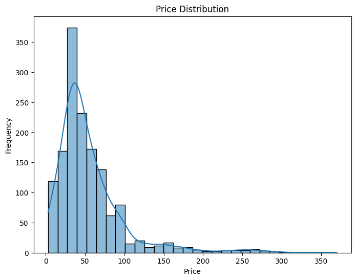

```python
plt.figure(figsize=(8, 6))
sns.histplot(products_df['Price'], bins=30, kde=True)
plt.title('Price Distribution')
plt.xlabel('Price')
plt.ylabel('Frequency')
plt.show()
```

This graphic shows that the prices with the highest frequency lie in the 25 to 50 dollar range. The distribution is right-skewed, meaning that while most products are more affordable, there are a few high-end products that significantly raise the upper price limit.

This is relevant to our analysis because identifying lower, average, and higher price ranges will allow us to extract products at different price points and dive deeper into their specific ingredient compositions. Understanding the price variation can help us investigate if higher prices are associated with products marketed as healthier or safer.

**Rank Distribution**

To explore how products are rated in the cosmetics dataset, we visualized the distribution of **product ranks** using a boxplot. This allows us to see the spread, central tendency, and presence of outliers in the ranking data.

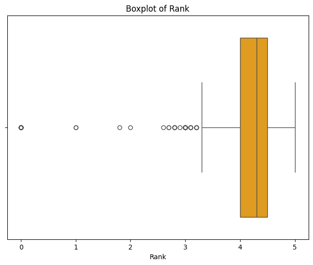

```python
plt.figure(figsize=(8, 6))
sns.boxplot(x=products_df['Rank'], color='orange')
plt.title('Boxplot of Rank')
plt.xlabel('Rank')
plt.show()
```

The boxplot shows that the majority of ranks fall between 4.0 and 4.5, which corresponds with the average rank of 4.15 and median rank of 4.30, as indicated in our summary statistics from data.describe(). The 25th and 75th percentiles are 4.0 and 4.5 respectively, which mirrors what we see in the boxplot above.

The boxplot also highlights some outliers below 3.0, representing products with notably lower ranks. By identifying these outliers and products near the median, we can further investigate what differentiates these products, both in terms of price and ingredients.

# Relationship between Price and Rank

Next, we investigate whether there is any relationship between a product's price and its rank. This analysis helps us understand:

- **Do higher-priced products tend to be rated more favorably?**
- **Or are rank and price independent of one another?**

To explore this relationship, we use a scatter plot, which provides a clear visualization of any potential trends or patterns.

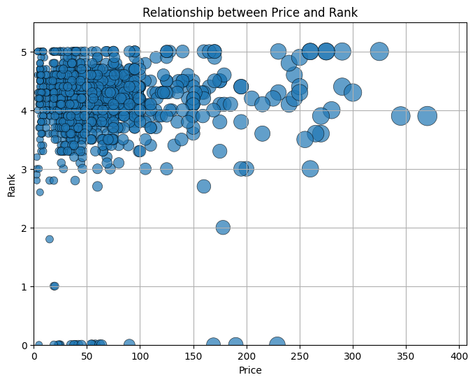

```
Correlation Between Price and Rank: -0.025214717679718862
```

```python
plt.figure(figsize=(8, 6))

sns.scatterplot(x='Price', y='Rank', data=products_df, alpha=0.7,
                edgecolor='black', linewidth=0.5,
                size='Price', sizes=(50, 400), legend=None)

plt.title('Relationship between Price and Rank')
plt.xlabel('Price')
plt.ylabel('Rank')
plt.xlim(0, products_df['Price'].max() * 1.1)
plt.ylim(0, products_df['Rank'].max() * 1.1)
plt.grid(True)
plt.show()

# Calculate and print the correlation
correl = products_df['Rank'].corr(products_df['Price'])
print("Correlation Between Price and Rank:", correl)
```

The correlation coefficient between price and rank is **-0.025**, indicating a very weak negative relationship. This means there is almost no linear correlation between price and rank, suggesting that variations in price do not significantly influence product rankings.

Overall, while our initial hypothesis suggested a potential positive correlation between higher prices and better rankings, the data indicates that this may not hold true in this context, highlighting the complexity of consumer preferences in the beauty and cosmetic industry.

## Price Analysis of Products by Label

To better understand pricing trends, we analyzed the average prices of products across different categories (labels). The bar chart below illustrates the mean price for each product label, offering insights into how pricing varies among product types.

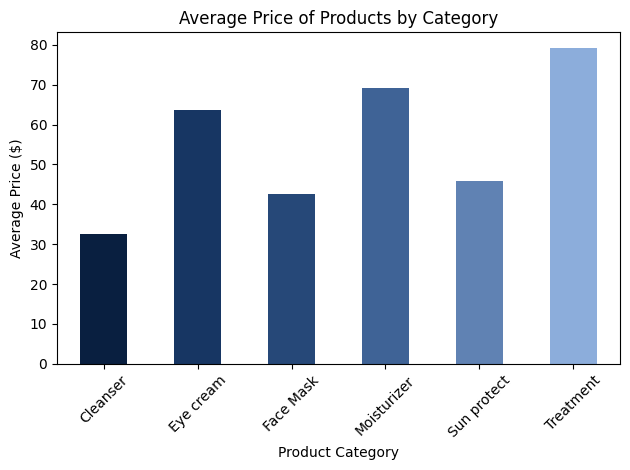

```python
# Define the color palette
colors2 = ["#091f40", "#173663", "#264878", "#3f6396", "#6082b3", "#8caddb"]

# Create the bar plot with mean prices grouped by label
products_df.groupby("Label")["Price"].mean().plot.bar(color=colors2)

# Add title and labels
plt.title("Average Price of Products by Category")
plt.xlabel("Product Category")
plt.ylabel("Average Price ($)")
plt.xticks(rotation=45)

# Show the plot
plt.tight_layout()
plt.figure(figsize=(8, 6))
plt.show()
```

The bar chart above illustrates the average prices for each product category (label) in our dataset, which includes six labels: **Cleanser, Eye Cream, Face Mask, Moisturizer, Sun Protect, and Treatment.**

**Key Observations:**

- The **Treatment** category has the highest average price, likely due to its specialized nature or use of premium ingredients.
- On the other hand, the **Cleanser** category has the lowest average price, suggesting it is more commonly available and potentially less expensive to produce.

The significant variation in pricing between categories highlights the diversity in the cosmetics market. It would be interesting to explore customer purchasing behavior and market trends.

# Analysis by Ingredient

Our research aims to uncover whether **higher-priced ingredients are associated with fewer health hazards**. To explore this relationship, we merged our two tidy DataFrames—one containing product information and the other listing ingredients. This integration allows us to analyze how product prices correlate with the ingredients they contain. For each ingredient, we calculated the average price of the products in which it is used.

## Price Distribution of Ingredients

We analyzed the distribution of **ingredient prices** to understand how different ingredients contribute to product pricing. This step helps us identify high-priced ingredients and sets the stage for examining their relationship with health hazards.

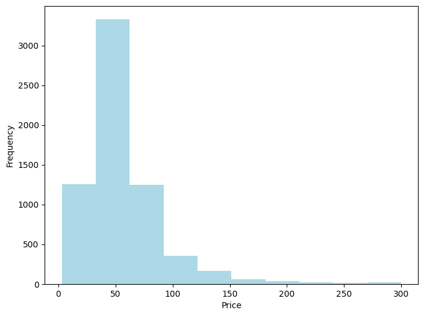

```python
# Reset the index for products_df
products_df = products_df.reset_index()

# Merge the ingredients df with products df to include prices
merged_df = ingredients_df.merge(products_df[['Product_ID', 'Price']], on='Product_ID')

# Group by ingredients and calculate the mean price for each ingredient
grouped = merged_df.groupby("Ingredients")["Price"].mean()
plt.figure(figsize=(8, 6))
grouped.plot.hist(xlabel = "Price", color = "lightblue")
```

The histogram above reveals key patterns in the distribution of ingredient prices:

- **Right-skewed distribution:** The majority of ingredients have an average price below $100, with only a small number of outliers commanding much higher prices.
- **Premium ingredients:** Ingredients with an average price exceeding $100 are significantly less common, likely reflecting their rarity or premium status. These high-priced ingredients may be associated with unique properties, such as enhanced effectiveness or perceived health benefits.

Our next step involves categorizing ingredients by price percentiles and analyzing their associated health hazard data.

# Categorizing Ingredients by Average Price Percentiles

To investigate the relationship between ingredient price and safety, we categorized ingredients into different percentiles based on their average price at intervals of 0.025, making adjustments where necessary.

For our preliminary analysis, we decided to observe trends based on four distinct categories: **Low, 25th Percentiles, Median, and High**. If the data provides meaningful insights at these larger intervals, we will use the smaller intervals to develop our model later on. For each price category, we selected the top 10 ingredients closest to these values.

This categorization provides a structured framework to compare ingredients across price tiers and investigate whether higher-priced ingredients are associated with fewer or different health hazards.

```python
# Calculate percentiles
percentiles = {
    "Min": grouped.min(),
    "2.5th": grouped.quantile(0.025),
    "5th": grouped.quantile(0.05),
    "7.5th": grouped.quantile(0.075),
    "10th": grouped.quantile(0.10),
    "12.5th": grouped.quantile(0.125),
    "16th": grouped.quantile(0.16),
    "17.5th": grouped.quantile(0.125),
    "20th": grouped.quantile(0.20),
    "22.5th": grouped.quantile(0.225),
    "25th": grouped.quantile(0.25),
    "27.5th": grouped.quantile(0.275),
    "30th": grouped.quantile(0.30),
    "32.5th": grouped.quantile(0.325),
    "35th": grouped.quantile(0.35),
    "37.5th": grouped.quantile(0.375),
    "40th": grouped.quantile(0.40),
    "42.5th": grouped.quantile(0.425),
    "46th": grouped.quantile(0.46),
    "47.5th": grouped.quantile(0.475),
    "Median": grouped.median(),
    "52.5th": grouped.quantile(0.525),
    "55th": grouped.quantile(0.55),
    "57.5th": grouped.quantile(0.575),
    "60th": grouped.quantile(0.60),
    "62.5th": grouped.quantile(0.625),
    "65th": grouped.quantile(0.65),
    "67.5th": grouped.quantile(0.675),
    "70th": grouped.quantile(0.70),
    "72.5th": grouped.quantile(0.725),
    "75th": grouped.quantile(0.75),
    "77.5th": grouped.quantile(0.775),
    "80th": grouped.quantile(0.80),
    "82.5th": grouped.quantile(0.825),
    "85th": grouped.quantile(0.85),
    "87.5th": grouped.quantile(0.875),
    "90th": grouped.quantile(0.91),
    "92.5th": grouped.quantile(0.925),
    "97.5th": grouped.quantile(0.975),
    "Max": grouped.max(),

}

# Add these to the categorization for display
categorized_ingredients = {}
for category, value in percentiles.items():
    if category in ["Min", "2.5th", "5th", "7.5th", "10th", "12.5th", "16th","17.5th","20th", "22.5th","25th","27.5th", "30th","32.5th", "35th","37.5th", "40th", "42.5th", "45th", "47.5th", "Median", "52.5th", "55th", "57.5th", "60th", "62.5th","65th", "67.5th", "70th", "72.5th","75th", "77.5th", "80th", "82.5th", "85th","87.5th", "90th", "92.5th", "97.5th","Max"]:
        ingredients = grouped[abs(grouped - value) < 0.01].sort_values(ascending=False).head(10)
    else:
        ingredients = grouped[grouped == value]
    categorized_ingredients[category] = ingredients

# Display the results
print("\n--- Price Analysis of Ingredients by Percentiles ---\n")
for category, ingredients in categorized_ingredients.items():
    print(f"{category} - Average Price:")
    if not ingredients.empty:
        for ingredient, price in ingredients.items():
            print(f"  {ingredient}: ${price:.2f}")
    else:
        print("No ingredients found in this category.")
    print("\n" + "-"*50 + "\n")
```

```
--- Price Analysis of Ingredients by Percentiles ---

Min - Average Price:
  Denatonium Benzoate.: $3.00
  Hamamelis Virginiana (Witch Hazel) Bark/Leaf/Twig Extract: $3.00
  Olive Oil Glycereth-8 Esters: $3.00
  Rosa Centifolia Flower Extract.: $3.00
  Sodium Saccharin: $3.00
  Vinyl Caprolactam/VP/Dimethylaminoethyl Methacrylate Copolymer: $3.00

--------------------------------------------------

2.5th - Average Price:
  -Vitamin A (retinol): Helps firm skin for a powerful anti-aging effect. -OxyForce™ Cellular Active (Perfluorodecalin): Helps support natural collagen synthesis: $12.00
  Kaolinite (White Clay): $12.00
  Lonicera Japonica Flower Extract (Lonicera Japonica (Honeysuckle) Flower): $12.00
  Melia Azadirachta Bark Extract: $12.00
  Melia Azadirachta LeafExtract: $12.00
  Menadione: $12.00
  Moringa OleiferaSeed Oil: $12.00
  Ocimum SanctumLeaf Extract: $12.00
  PEG-450: $12.00
  PEG-60: $12.00

--------------------------------------------------

5th - Average Price:
  -Charcoal -Snow Lotus: $19.00
  -Homosalate 10%: $19.00
  Oryza Sativa(Rice) Bran Extract: $19.00
  Olive Oil PEG-7 Esters: $19.00
  Musa Sapientum(Banana) Fruit Extract: $19.00
  Methylglucamine: $19.00
  Methyl Glucose Dioleate: $19.00
  Malva Sylvestris(Mallow) Extract: $19.00
  Magnolia Liliflora Flower Extract: $19.00
  Linum Usitatissimum(Linseed) Seed Extract: $19.00

--------------------------------------------------

```

[output cut: 443 more lines]

```
  Vinolevure: $150.00
  Viniferine: $150.00
  Vinergy Complex: $150.00
  Vine Resveratrol: $150.00
  Spirulina Platensis (Algae) Powder: $150.00
  Simmondsia Chinensis Seed Oil/Simmondsia Chinensis (Jojoba) Seed Oil: $150.00
  Sea Salt\Maris Sal\Sel Marin: $150.00
  Quercus Suber Bark Extract: $150.00

--------------------------------------------------

Max - Average Price:
  Rubus Suavissimus (Raspberry) Leaf Extract: $300.00

--------------------------------------------------
```

After categorizing ingredients into specific price ranges, the next step is to examine their associated **health effects**. By utilizing hazard data from relevant databases, we aim to uncover potential links between ingredient price and health risks. By analyzing these chemicals, we hope to gain deeper insights into the relationship between ingredient cost and safety standards.

# Next Datasets: Analyzing Specific Chemicals' Hazard Data

To deepen our analysis, we incorporated data from **ECHA Europa's C & L Inventory** Database, which offers detailed hazard classification records for chemicals based on submissions from companies and manufacturers. This dataset is essential for evaluating the health risks associated with cosmetic ingredients.

Since the data is organized on a chemical-by-chemical basis, we focused our analysis on ingredients from key points along the price spectrum: low extreme, 25th percentile, median (50th percentile), and 75th percentile to maximum. These categories provide a representative range of ingredient pricing, allowing us to investigate potential relationships between price and associated health hazards.

**Selected Ingredients by Price Categories:**

**Low:**

- Denatonium Benzoate
- Hamamelis Virginiana (Witch Hazel) Bark/Leaf/Twig Extract
- Rosa Centifolia Flower Extract
- Sodium Saccharin

**25th Percentile:**

- Rosa Damascena Flower Extract
- Sal Marin (Sea Salt)
- Rubus Idaeus (Raspberry) Seed Oil
- Rosmarinus Officinalis (Rosemary) Leaf Oil
- Rosa Canina

**Median:**

- Jojoba Oil
- Palmitic Acid
- Patended Echinea Purpurea 'Greenenvytm' Root Extract

**75th Percentile to Maximum:** (Grouped due to data scarcity for individual ingredients)

- Glycine (Soybean) Soja Extract
- Cetyl Alcohol Plymethylsilsesquioxane
- Alpha Bisabol
- Titricum Vulgare (Wheat) Flour Lipids

**Exclusions**

Some chemicals were excluded from this analysis due to factors such as:

- Lack of a discrete chemical structure
- Insufficient data availability
- Redundant or repetitive composition

**Hazard Codes**

Each chemical may be associated with one or more hazard codes. These codes denote potential health risks or environmental impacts, and our analysis focuses on the following:

- H225 - Highly Flammable Liquid & Vapor
- H226 - Flammable Liquid & Vapor
- H302 - Harmful if swallowed
- H304 - May be fatal if swallowed or enters airways
- H312 - Harmful if in contact with skin
- H315 - Causes skin irritation
- H317 - May cause allergic reaction
- H318 - Causes serious eye damage
- H319 - Causes serious eye irritation
- H330 - Fatal if inhaled
- H331 - Toxic if inhaled
- H332 - Harmful if inhaled
- H335 - May cause respiratory irritation (split into further categories)
- H336 - May cause drowsiness or dizziness
- H341 - Suspected of causing genetic defects
- H351 - Suspected of causing cancer
- H371 - May cause damage to organs
- H373 - May cause damage to organs through repeated exposure
- H400 - Very toxic to aquatic life
- H410 - Very toxic to aquatic life with long lasting effects
- H411 - Toxic to aquatic life with long lasting effects
- H412 - Harmful to aquatic life
- H413 - May cause long lasting harmful effects to aquatic life

## ETL and EDA -- ECHA Europa C & L Library

To analyze the selected chemicals, we utilized the ECHA Europa database to extract their hazard data. Using a **custom-built function**, we scraped the ECHA Europa website for the hazard information of each chemical, organized the data into a dictionary of URLs, and subsequently processed it into a consolidated DataFrame. This allowed us to generate heat maps to visualize the distribution and severity of hazards across different chemicals.

### Hazard Data for Lowest Price Chemicals

In this section, we focus on chemicals associated with the **lowest price range** in our dataset. These ingredients are often found in budget-friendly products. By analyzing their hazard data, we aim to determine whether lower-priced ingredients pose greater health risks compared to higher-priced ones.

```
--- Hazard Summary for Lowest Price Chemicals ---
```

| Chemical Hazard Statement Code(s) | Denatonium Benzoate | Hamamelis Virginiana | Rosa Centifolia Flower Extract | Sodium Saccharin |
| --- | --- | --- | --- | --- |
| H226 | 0 | 53 | 0 | 0 |
| H302 | 2218 | 0 | 0 | 9 |
| H312 | 1 | 0 | 0 | 1 |
| H315 | 187 | 0 | 158 | 1 |
| H317 | 1 | 0 | 164 | 0 |
| H318 | 760 | 0 | 23 | 0 |
| H319 | 84 | 0 | 140 | 1 |
| H330 | 113 | 0 | 0 | 0 |
| H331 | 11 | 0 | 0 | 0 |
| H332 | 1960 | 0 | 0 | 1 |
| H335 | 108 | 0 | 0 | 2 |
| H336 | 1 | 0 | 0 | 0 |
| H341 | 0 | 0 | 151 | 0 |
| H350 | 0 | 0 | 0 | 3 |
| H351 | 0 | 0 | 151 | 2 |
| H411 | 0 | 0 | 2 | 0 |
| H412 | 1956 | 0 | 16 | 0 |

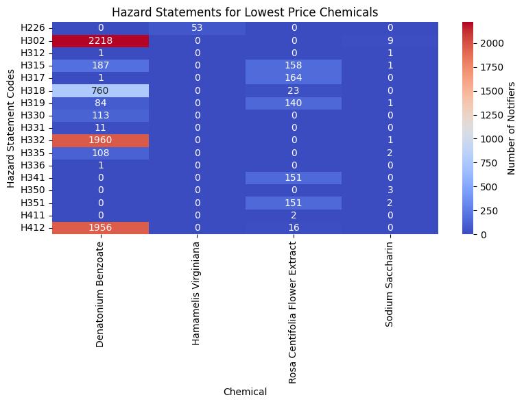

```python
# Function to fetch and clean data from a given URL
def fetch_and_clean_chemical_data(url):
    try:
        response = requests.get(url, timeout=10)
        response.raise_for_status()

        # Parse the HTML content
        soup = BeautifulSoup(response.content, 'html.parser')
        html_tables = str(soup.find_all("table"))
        df = pd.read_html(StringIO(html_tables))[1]  # Select the relevant table

        # Clean the dataset
        df.columns = df.columns.droplevel(0)
        columns_to_drop = [
            "Supplementary Hazard Statement Code(s)",
            "Specific Concentration limits, M-Factors",
            "Notes",
            "Classification affected by Impurities / Additives",
            "Joint Entries",
            "Unnamed: 11_level_1"
        ]
        df = df.drop(columns=columns_to_drop, errors='ignore')  # Ignore errors if columns are missing
        df.columns = [
            "Hazard Class and Category Code(s)",
            "Hazard Statement Code(s)",
            "Hazard Statement Code(s), Extended",
            "Pictograms, Signal Word Code(s)",
            "Additional Notified Information",
            "Number of Notifiers"
        ]
        return df
    except:
        return None

# Dictionary of chemicals
lowest_price_chemicals = {
    "Denatonium Benzoate": 'https://echa.europa.eu/information-on-chemicals/cl-inventory-database/-/discli/details/17558',
    "Hamamelis Virginiana": 'https://echa.europa.eu/information-on-chemicals/cl-inventory-database/-/discli/details/14742',
    "Rosa Centifolia Flower Extract": 'https://echa.europa.eu/information-on-chemicals/cl-inventory-database/-/discli/details/9565',
    "Sodium Saccharin": 'https://echa.europa.eu/information-on-chemicals/cl-inventory-database/-/discli/details/18951'
}

# Fetch and Combine Data
lowest_price_data = []

for chemical, url in lowest_price_chemicals.items():
    df = fetch_and_clean_chemical_data(url)
    if df is not None:
        df["Chemical"] = chemical
        lowest_price_data.append(df)

# Combine all data
if lowest_price_data:
    combined_lowest_df = pd.concat(lowest_price_data, ignore_index=True)
    combined_lowest_df["Hazard Statement Code(s)"] = combined_lowest_df["Hazard Statement Code(s)"].str.slice(0, 4)

    # Aggregate Hazard Data
    hazard_summary = combined_lowest_df.pivot_table(
        index="Hazard Statement Code(s)",
        columns="Chemical",
        values="Number of Notifiers",
        aggfunc="sum",
        fill_value=0
    )

    # Display the summary pivot table
    print("\n--- Hazard Summary for Lowest Price Chemicals ---")
    display(hazard_summary)

    # Heatmap to visualize hazards across chemicals
    plt.figure(figsize=(8, 6))
    sns.heatmap(hazard_summary, annot=True, fmt="d", cmap="coolwarm", cbar_kws={'label': 'Number of Notifiers'})
    plt.title("Hazard Statements for Lowest Price Chemicals", fontsize=12)
    plt.xlabel("Chemical")
    plt.ylabel("Hazard Statement Codes")
    plt.tight_layout()
    plt.show()
```

As shown above, while Hamamelis Virginiana, Rosa Centifolia, and Sodium Saccharin have limited hazard reports, Denatonium Benzoate stands out with a very high number of hazard notifications. The top three hazard codes for Denatonium Benzoate are H302 (harmful if swallowed), H332 (harmful if inhaled), and H412 (harmful to aquatic life), each with thousands of reports.

Rosa Centifolia also exhibits a notable number of notifiers, particularly for codes H315 (causes skin irritation), H317 (may cause allergic skin reactions), H319 (causes serious eye irritation), H341 (suspected of causing genetic defects), and H351 (suspected of causing cancer).

This analysis provides valuable insight into the hazard reports associated with lower-priced chemicals. It suggests that examining additional ingredients with average prices within similar low-percentile ranges could yield comparable results, reinforcing the trend observed in this analysis.

### Hazard Data for 25th Percentile Price Chemicals

Here, we examine chemicals from the **25th percentile price range**, representing slightly more expensive ingredients than the lowest price category. This analysis helps us explore whether moderate increases in price correspond to differences in health hazard profiles.

```
--- Hazard Summary for 25th Percentile Price Chemicals ---
```

| Chemical Hazard Statement Code(s) | Perfluorodimethylcyclohexane | Rosa Canina | Rosa Damascena Flower Extract | Rosmarinus Officinalis | Rubus Ideauus (Red Raspberry) Seed Oil | Sal Marin (Sodium Chloride) |
| --- | --- | --- | --- | --- | --- | --- |
| H225 | 0 | 0 | 1 | 0 | 1288 | 0 |
| H226 | 0 | 40 | 1307 | 1 | 44 | 0 |
| H302 | 0 | 0 | 1 | 0 | 0 | 0 |
| H304 | 0 | 0 | 2 | 1 | 0 | 0 |
| H312 | 0 | 0 | 1 | 0 | 0 | 0 |
| H313 | 0 | 0 | 2 | 0 | 0 | 0 |
| H315 | 41 | 173 | 1766 | 1 | 0 | 2 |
| H316 | 0 | 0 | 0 | 0 | 0 | 1 |
| H317 | 0 | 161 | 1764 | 1 | 0 | 0 |
| H318 | 0 | 148 | 1757 | 0 | 0 | 0 |
| H319 | 41 | 14 | 8 | 1 | 0 | 215 |
| H320 | 0 | 0 | 0 | 0 | 0 | 1 |
| H335 | 78 | 0 | 0 | 0 | 0 | 0 |
| H341 | 0 | 3 | 1601 | 0 | 0 | 0 |
| H351 | 0 | 145 | 1602 | 0 | 0 | 0 |
| H371 | 0 | 0 | 0 | 1 | 0 | 0 |
| H373 | 0 | 0 | 0 | 0 | 0 | 13 |
| H400 | 0 | 0 | 1 | 1 | 0 | 0 |
| H401 | 0 | 0 | 2 | 0 | 0 | 0 |
| H410 | 0 | 0 | 0 | 1 | 0 | 0 |
| H411 | 0 | 146 | 10 | 0 | 0 | 0 |
| H412 | 0 | 14 | 1537 | 0 | 0 | 0 |

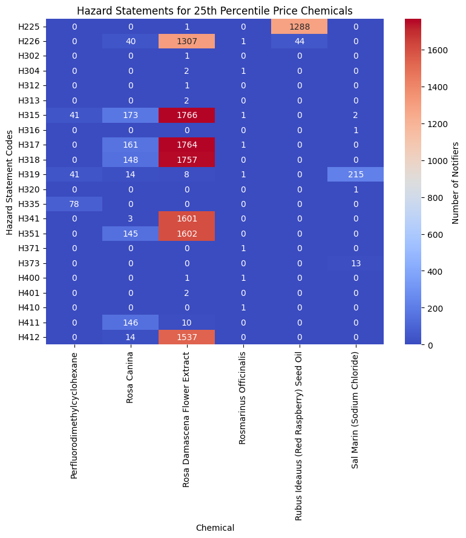

```python
q25_price_chemicals = {
    "Rosa Damascena Flower Extract": 'https://echa.europa.eu/information-on-chemicals/cl-inventory-database/-/discli/details/59500',
    "Perfluorodimethylcyclohexane": 'https://echa.europa.eu/information-on-chemicals/cl-inventory-database/-/discli/details/49686',
    "Sal Marin (Sodium Chloride)": 'https://echa.europa.eu/information-on-chemicals/cl-inventory-database/-/discli/details/103945',
    "Rubus Ideauus (Red Raspberry) Seed Oil": 'https://echa.europa.eu/information-on-chemicals/cl-inventory-database/-/discli/details/104503',
    "Rosmarinus Officinalis": 'https://echa.europa.eu/information-on-chemicals/cl-inventory-database/-/discli/details/175142',
    "Rosa Canina": 'https://echa.europa.eu/information-on-chemicals/cl-inventory-database/-/discli/details/116152'
}

q25_price_data = []

for chemical, url in q25_price_chemicals.items():
    df = fetch_and_clean_chemical_data(url)
    if df is not None:
        df["Chemical"] = chemical
        q25_price_data.append(df)

if q25_price_data:
    # Combine all data
    combined_q25_df = pd.concat(q25_price_data, ignore_index=True)
    combined_q25_df["Hazard Statement Code(s)"] = combined_q25_df["Hazard Statement Code(s)"].str.slice(0, 4)

    # Aggregate Hazard Data
    hazard_summary = combined_q25_df.pivot_table(
        index="Hazard Statement Code(s)",
        columns="Chemical",
        values="Number of Notifiers",
        aggfunc="sum",
        fill_value=0
    )

    print("\n--- Hazard Summary for 25th Percentile Price Chemicals ---\n")
    display(hazard_summary)

    # Heatmap
    plt.figure(figsize=(8, 9))
    sns.heatmap(hazard_summary, annot=True, fmt="d", cmap="coolwarm", cbar_kws={'label': 'Number of Notifiers'})
    plt.title("Hazard Statements for 25th Percentile Price Chemicals", fontsize=12)
    plt.xlabel("Chemical")
    plt.ylabel("Hazard Statement Codes")
    plt.tight_layout()
    plt.show()
    plt.savefig('filename.png')
```

Next, at the 25th percentile, we analyzed the ingredients listed above. Most of these ingredients exhibit only a few specific hazard ratings, such as Sodium Chloride (Sal Marin) being associated with serious eye irritation (H319).

A particularly notable observation is the high number of notifiers for Rosa Damascena Flower Extract. This ingredient is linked to several hazard codes, including H226 (flammability), H315 (skin irritation), H317 (skin allergies), H318 (eye irritation), H341 (genetic defects), H351 (cancer), and H412 (harmfulness to aquatic life). Interestingly, while both Rosa Damascena and Rosa Centifolia belong to the same genus, Rosa, Rosa Damascena exhibits significantly more health hazards, even though Rosa Centifolia is associated with a lower average price. This contrast highlights that higher pricing does not always correlate with fewer health risks, emphasizing the need for deeper analysis into the relationship between ingredient composition, pricing, and health impacts.

### Hazard Data for Median Price Chemicals

The median price range reflects ingredients commonly found in **mid-range products**. By analyzing these chemicals, we aim to identify any trends in hazard data and determine if median-priced ingredients are safer than those in lower price categories.

```
--- Hazard Summary for Median Price Chemicals ---
```

| Chemical Hazard Statement Code(s) | Jojoba Oil | Palmitic Acid | Patented Echinacea Purpurea 'Greenenvytm' Root Extract |
| --- | --- | --- | --- |
| H226 | 0 | 0 | 4 |
| H315 | 0 | 518 | 0 |
| H319 | 1 | 539 | 0 |
| H332 | 6 | 0 | 0 |
| H335 | 0 | 509 | 0 |
| H412 | 0 | 73 | 0 |
| H413 | 1 | 1 | 0 |

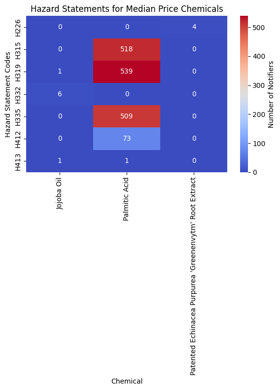

```python
med_price_chemicals = {
    "Jojoba Oil": 'https://echa.europa.eu/information-on-chemicals/cl-inventory-database/-/discli/details/127307',
    "Palmitic Acid": 'https://echa.europa.eu/information-on-chemicals/cl-inventory-database/-/discli/details/12145',
    "Patented Echinacea Purpurea 'Greenenvytm' Root Extract": 'https://echa.europa.eu/information-on-chemicals/cl-inventory-database/-/discli/details/83007',
}

med_price_data = []

for chemical, url in med_price_chemicals.items():
    df = fetch_and_clean_chemical_data(url)
    if df is not None:
        df["Chemical"] = chemical
        med_price_data.append(df)

if med_price_data:
    # Combine all data f
    combined_med_df = pd.concat(med_price_data, ignore_index=True)
    combined_med_df["Hazard Statement Code(s)"] = combined_med_df["Hazard Statement Code(s)"].str.slice(0, 4)

    # Aggregate Hazard Data
    hazard_summary = combined_med_df.pivot_table(
        index="Hazard Statement Code(s)",
        columns="Chemical",
        values="Number of Notifiers",
        aggfunc="sum",
        fill_value=0
    )

    # Display the hazard summary pivot table
    print("\n--- Hazard Summary for Median Price Chemicals ---\n")
    display(hazard_summary)

    # Heatmap
    plt.figure(figsize=(6,8))
    sns.heatmap(hazard_summary, annot=True, fmt="d", cmap="coolwarm", cbar_kws={'label': 'Number of Notifiers'})
    plt.title("Hazard Statements for Median Price Chemicals", fontsize=12)
    plt.xlabel("Chemical")
    plt.ylabel("Hazard Statement Codes")
    plt.tight_layout()
    plt.show()
```

At the median price, the number of health hazard notifications shows a noticeable decrease. Ingredients such as Jojoba Oil and Echinacea Purpurea have little to no hazard notifications, suggesting a lower risk profile. However, Palmitic Acid stands out with reported hazard codes H315 (skin irritation), H319 (eye irritation), and H335 (respiratory irritation), indicating that even within the median price range, some ingredients may still pose potential health risks. This finding underscores the variability in health impacts across ingredients, even within the same price category.

### Hazard Data for Highest Price Chemicals

In this section, we analyze chemicals associated with the **highest price range**, often found in premium and luxury products. This analysis helps us evaluate whether premium pricing is justified by the inclusion of safer or less hazardous ingredients.

```
--- Hazard Summary for High Price Chemicals ---
```

| Chemical Hazard Statement Code(s) | Alpha Bisabolol | Cetyl Alcohol Polymethylsilsesquioxane | Glycine (Soybean) Soja Extract | Triticum Vulgare (Wheat) Flour Lipids |
| --- | --- | --- | --- | --- |
| H225 | 0 | 72 | 0 | 0 |
| H300 | 3 | 0 | 0 | 0 |
| H302 | 0 | 73 | 0 | 0 |
| H312 | 0 | 72 | 0 | 0 |
| H315 | 0 | 294 | 0 | 0 |
| H317 | 229 | 0 | 0 | 78 |
| H319 | 0 | 735 | 1 | 0 |
| H335 | 0 | 118 | 1 | 0 |
| H336 | 0 | 72 | 0 | 0 |
| H400 | 0 | 290 | 0 | 0 |
| H410 | 0 | 151 | 0 | 0 |
| H411 | 271 | 289 | 0 | 0 |
| H412 | 0 | 253 | 0 | 0 |
| H413 | 0 | 267 | 0 | 0 |

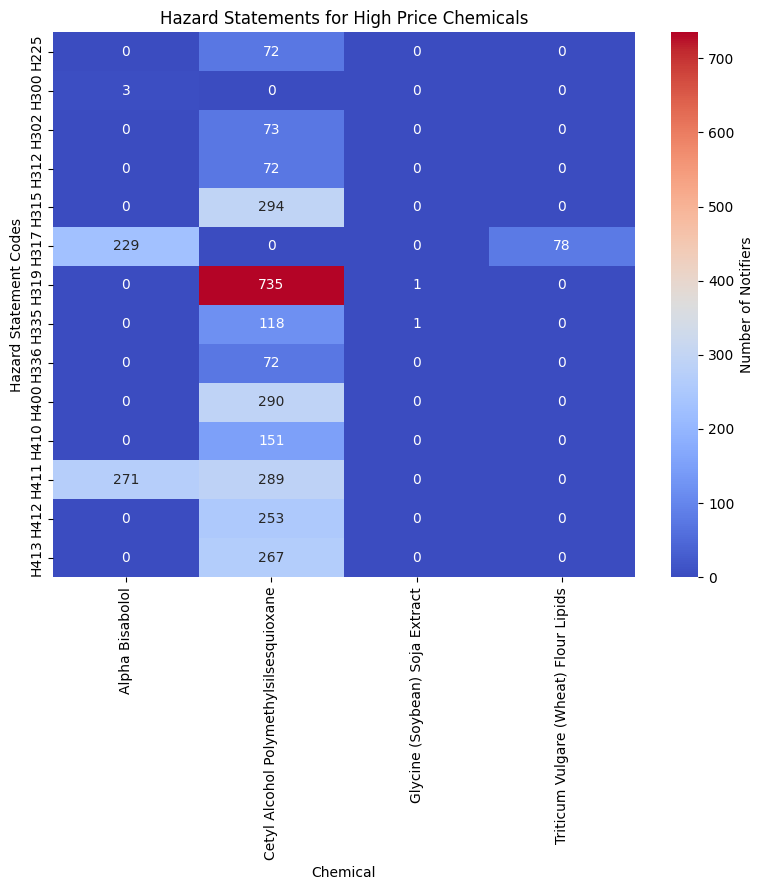

```python
high_price_chemicals = {
    "Glycine (Soybean) Soja Extract": 'https://echa.europa.eu/information-on-chemicals/cl-inventory-database/-/discli/details/94710',
    "Cetyl Alcohol Polymethylsilsesquioxane": 'https://echa.europa.eu/information-on-chemicals/cl-inventory-database/-/discli/details/28368',
    "Triticum Vulgare (Wheat) Flour Lipids": 'https://echa.europa.eu/information-on-chemicals/cl-inventory-database/-/discli/details/625',
    "Alpha Bisabolol": 'https://echa.europa.eu/information-on-chemicals/cl-inventory-database/-/discli/details/77543'}

# Fetch and analyze
high_price_data = []

for chemical, url in high_price_chemicals.items():
    df = fetch_and_clean_chemical_data(url)
    if df is not None:
        df["Chemical"] = chemical
        high_price_data.append(df)

if high_price_data:
    # Combine all data
    combined_high_df = pd.concat(high_price_data, ignore_index=True)
    combined_high_df["Hazard Statement Code(s)"] = combined_high_df["Hazard Statement Code(s)"].str.slice(0, 4)

    # Aggregate Hazard Data
    hazard_summary = combined_high_df.pivot_table(
        index="Hazard Statement Code(s)",
        columns="Chemical",
        values="Number of Notifiers",
        aggfunc="sum",
        fill_value=0
    )

    # Display the hazard summary pivot table
    print("\n--- Hazard Summary for High Price Chemicals ---\n")
    display(hazard_summary)

    # Heatmap
    plt.figure(figsize=(8, 9))
    sns.heatmap(hazard_summary, annot=True, fmt="d", cmap="coolwarm", cbar_kws={'label': 'Number of Notifiers'})
    plt.title("Hazard Statements for High Price Chemicals", fontsize=12)
    plt.xlabel("Chemical")
    plt.ylabel("Hazard Statement Codes")
    plt.tight_layout()
    plt.show()
```

At the high end of the price spectrum, the frequency of health hazard notifications is noticeably reduced compared to the lower price extremes. While some hazards are still reported, they are generally fewer and less severe. The most prominent hazards at this level are H319 and H315, associated with Cetyl Alcohol. This observation supports the notion that higher-priced ingredients may correlate with fewer health risks, though exceptions like cetyl alcohol highlight that even premium ingredients are not entirely risk-free.

# Comparing Hazard Distributions Across Price Categories

In this section, we examine the aggregated hazard notifications across the four price categories: **Lowest Price, 25th Percentile, Median Price, and Highest Price.** By summarizing the total number of hazard notifications and visualizing the distribution of hazard codes (e.g., H302, H412) for each category, we aim to uncover trends and differences in chemical risks associated with varying price ranges.

However, since each price category contains a different number of ingredients, comparing the total number of hazard notifications directly could lead to biased conclusions. To address this, we normalized the hazard data by dividing the total number of hazard notifications for each hazard code by the number of unique ingredients in that price category. This normalization ensures a fair comparison by representing the **average number of notifications per ingredient**, rather than the raw totals.

This analysis allows us to explore whether higher-priced ingredients are associated with fewer or less severe health hazards, or if risks persist across all price tiers. Understanding these patterns provides valuable insights into the relationship between product cost and safety, helping to answer critical questions, such as whether higher prices translate to safer products or if lower price ranges consistently feature riskier chemicals. Ultimately, this comparison contributes to a deeper understanding of the potential trade-offs between ingredient cost and consumer health, informing both consumer decisions and industry practices.

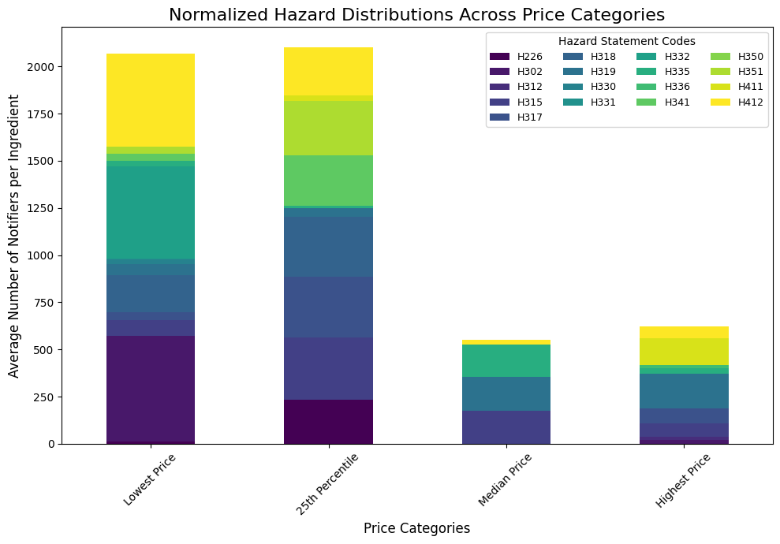

```python
# Aggregate and normalize hazard data for each category
categories = {
    "Lowest Price": combined_lowest_df,
    "25th Percentile": combined_q25_df,
    "Median Price": combined_med_df,
    "Highest Price": combined_high_df
}

# Initialize an empty DataFrame for normalized hazard data
normalized_hazard_summary = pd.DataFrame()

# Process each category and normalize
for category, df in categories.items():
    # Aggregate the hazard data
    aggregated = df.pivot_table(
        index="Hazard Statement Code(s)",
        values="Number of Notifiers",
        aggfunc="sum",
        fill_value=0
    )

    # Normalize by dividing by the number of unique chemicals in the category
    num_ingredients = df["Chemical"].nunique()  # Count unique ingredients
    normalized_hazard_summary[category] = aggregated.sum(axis=1) / num_ingredients

# Clean up the hazard codes
normalized_hazard_summary.index = normalized_hazard_summary.index.str.slice(0, 4)

# Plot
plt.figure(figsize=(12, 8))
normalized_hazard_summary.T.plot(kind="bar", stacked=True, figsize=(10, 7), colormap="viridis")
plt.title("Normalized Hazard Distributions Across Price Categories", fontsize=16)
plt.ylabel("Average Number of Notifiers per Ingredient", fontsize=12)
plt.xlabel("Price Categories", fontsize=12)
plt.xticks(rotation=45, fontsize=10)

plt.legend(
    title="Hazard Statement Codes",
    title_fontsize=10,
    fontsize=9,
    loc='upper right',
    ncol=4
)
plt.tight_layout()
plt.show()
```

The stacked bar chart reveals a clear trend in hazard distributions across price categories. The **25th Percentile** category exhibits the highest total number of hazard notifications, even surpassing the Lowest Price category. This suggests that some mid-priced products may rely on more hazardous ingredients.

Lower-priced products also show significant hazard diversity, with common hazards including:

- **H302:** Harmful if swallowed
- **H412:** Harmful to aquatic life

In contrast, the **Median** Price and **Highest** Price categories feature fewer notifiers and a narrower range of hazards. This supports the hypothesis that higher-priced products may prioritize safer ingredients. However, it’s important to note that even high-priced products are not entirely free of hazards.

Overall, these results indicate a general trend of fewer hazards in higher-priced products. However, the exceptions, particularly in the 25th Percentile category, warrant further investigation to better understand the factors contributing to these anomalies.

# Predicting Hazard Severity Using EWG Skin Deep Database

Now, we are going to build a **regression model** to **predict hazard severity based on the price of cosmetic ingredients**. This model will help us uncover whether higher-priced ingredients are associated with lower health risks, providing actionable insights into the relationship between cost and safety.

While our earlier analysis using the **ECHA Europa database** allowed us to observe trends between price and hazard notifications, many of the hazard codes—such as those related to ingestion or eye contact—were not directly relevant to how cosmetic products are typically used. However, hazards involving skin contact or inhalation were still meaningful and validated the potential for building this model.

To improve the relevance of our predictions, we turned to the **Environmental Working Group's Skin Deep database**, which assigns a 1-10 rating to cosmetic ingredients. This rating system evaluates health impacts based on factors like **carcinogenic potential, immunotoxicity, and reproductive toxicity**, making it highly relevant to the cosmetic industry. A rating of 1 indicates the safest ingredients, while 10 signifies the most hazardous.

We decided that this database was more relevant for our analysis because it focuses on health impacts directly related to cosmetic use, rather than providing general hazard data like ECHA Europa. For each price point, we identified the ingredients and retrieved their corresponding EWG ratings.

```python
ewg = pd.read_excel('ewg_rating.xlsx')
ewg_clean = ewg.dropna()
```

We began by reading an Excel file containing the EWG ratings for the ingredients we selected earlier. This file was created by combining the **average price data** extracted from the cosmetics dataset with the ratings **found in the EWG database**, and it was loaded into a clean DataFrame for analysis.

To explore the relationship between ingredient price and hazard ratings, we visualized the data using a scatterplot. The majority of ratings fall between **1 and 4**, indicating that most ingredients are classified as "good" in terms of safety. Ratings above **4** are clear outliers, suggesting a smaller subset of ingredients with higher hazard levels.

This exploratory data analysis (EDA) provided unexpected insights as way more ingredients have a "good" rating than expected when looked at through a cosmetic context.

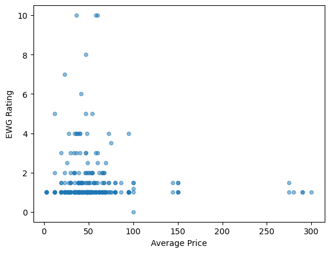

```python
ewg_clean.plot.scatter(x="Average Price", y = "EWG Rating", alpha=.5);
```

## Building the K-Nearest Neighbors (KNN) Model to Predict EWG Rating

By using this model, we aim to uncover whether a simple feature like price can effectively predict hazard ratings, providing valuable insights into the relationship between cost and safety in cosmetics.

```python
features = ["Average Price", "Chemical"]

x_train_dict = ewg_clean[features].to_dict(orient="records")
x_new_dict = [{
    "Average Price": 50,
    "Chemical": 'Phenoxythanol'
}]
y_train = ewg_clean["EWG Rating"]

# Dummy encoding
vec = DictVectorizer(sparse=False)
vec.fit(x_train_dict)
x_train = vec.transform(x_train_dict)
x_new = vec.transform(x_new_dict)

# scaling the data using standardization
scaler = StandardScaler()
scaler.fit(x_train)
x_train_sc = scaler.transform(x_train)
x_new_sc = scaler.transform(x_new)

# K-Nearest Neighbors Model will find the specified # of neighbors
model = KNeighborsRegressor(n_neighbors=30)
model.fit(x_train_sc, y_train)
model.predict(x_new_sc)
```

```
array([1.38333333])
```

After testing the model with several different price points and chemicals, we observed that it typically predicts an EWG Rating between 1 and 2, which aligns closely with the distribution of the data in our scatterplot. This indicates that most ingredients in our dataset are considered relatively safe.

Our analysis and modeling reveal that higher-priced products do not always guarantee safety. While prices exceeding $100 are outliers in our dataset, the data between 0 and 100 is substantial enough to demonstrate a consistent trend: ingredients within this range tend to have EWG ratings under 4. This consistency suggests that, beyond a certain price point, additional cost may not significantly correlate with safer ingredients.

By building this model, we provide a nuanced perspective on the relationship between ingredient price and safety, challenging the assumption that higher cost inherently equates to better health standards.

# Our Final Conclusion: What Our Data Revealed

Through this analysis, we explored the relationship between price, ingredient composition, and safety in the cosmetics industry. Our data revealed that while higher-priced products often convey an impression of better safety, this may not always be the case. With our results, we observed that mid-priced products sometimes contain more hazardous ingredients than even the lowest-priced ones, challenging assumptions about price and quality.

A closer look at hazard distributions indicated that premium-priced ingredients may prioritize safer formulations, but even these are not entirely hazard-free. The EWG model further solidified these findings, showing that most ingredients fall within a relatively safe range, regardless of price. Interestingly, extreme outliers in both price and hazard rating were rare, suggesting that the majority of cosmetics exist within a consistent safety standard.

Our data underscores the importance of transparency in ingredient labeling and the need for consumers to rely on evidence-based tools, such as the EWG database, to make informed decisions. **Price alone is not a definitive indicator of safety**, and understanding the underlying data can empower consumers and guide better industry practices.

```python
from google.colab import drive
drive.mount('/content/drive')

!jupyter nbconvert --to html '/content/drive/My Drive/Colab Notebooks/Final.ipynb'
```

```
[NbConvertApp] Converting notebook /content/drive/My Drive/Colab Notebooks/Final.ipynb to html
[NbConvertApp] WARNING | Alternative text is missing on 5 image(s).
[NbConvertApp] Writing 771423 bytes to /content/drive/My Drive/Colab Notebooks/Final.html
```